# Albacore Diet Synthesis C

### Species models

**SPP Manyglm - Predator Life Stage** add:, eval=FALSE

```r
prob_life_spp <- traitglm(L = alb_prob_preyPA_mv,
                          R = alb_prob_covars$pred_life,
                          family=binomial(link = "logit")
                          ) #note default is "manyglm"
```

**SPP Manyglm - Ocean Basin**

```r
prob_ocean_spp <- traitglm(L = alb_prob_preyPA_mv,
                                    R = alb_prob_covars$OceanBasin,
                                    family=binomial(link = "logit")
                                    ) #note default is "manyglm"

#check model output if needed
```

**SPP Manyglm - Latitude**

```r
prob_lat_spp <- traitglm(L = alb_prob_preyPA_mv,
                         R = alb_prob_covars$lat_cat,
                         family=binomial(link = "logit")
                         ) #note default is "manyglm"

#check model output if needed
```

**SPP Manyglm - Life Stage - Check multivariate model outputs**

Note that multivariate residuals look good and we have a pretty good fit.

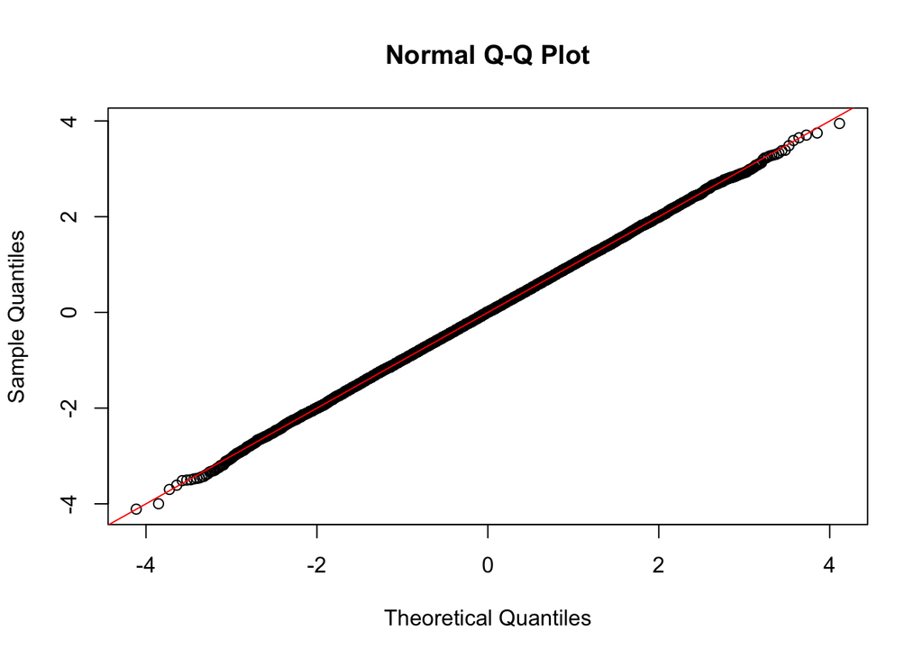

```r
# Check model output - residuals TEST
qqnorm(residuals(prob_life_spp)[which(residuals(prob_life_spp) < 10000)])
abline(c(0, 1), col = "red")
```

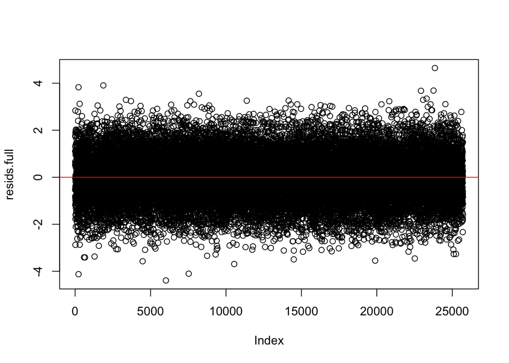

```r
# omit non-finite residuals FULL MODEL
resids.full = residuals(prob_life_spp)[is.finite((residuals(prob_life_spp)))]
plot(resids.full)
abline(c(0, 0), col = "red")
```

SAVE OUTPUTS SO FAR

```r
#/Users/tashhardy/Documents/GitHub/albacore-diet-global/outputs_figures/traitglms/prob_models

saveRDS(prob_life_spp, file = here("outputs_figures/traitglms/prob_models/prob_life_spp.rds"))
saveRDS(prob_ocean_spp, file = here("outputs_figures/traitglms/prob_models/prob_ocean_spp.rds"))
saveRDS(prob_lat_spp, file = here("outputs_figures/traitglms/prob_models/prob_lat_spp.rds"))
```

### Trait clusters models

#### Predator Life Stage

**MANYGLM Clusters - Predator Life Stage**

Trait (cluster)*Env (life stage) - Manyglm

```r
prob_life_clusters_many <- traitglm(L = alb_prob_preyPA_mv,
                                    R = alb_prob_covars$pred_life,
                                    Q = traits_use$cluster,
                                    family=binomial(link = "logit")
                                    ) #note default is "manyglm"
```

Note that outputs for all models look the same because residuals are the same, as we fit models to the same species and covariate datasets.

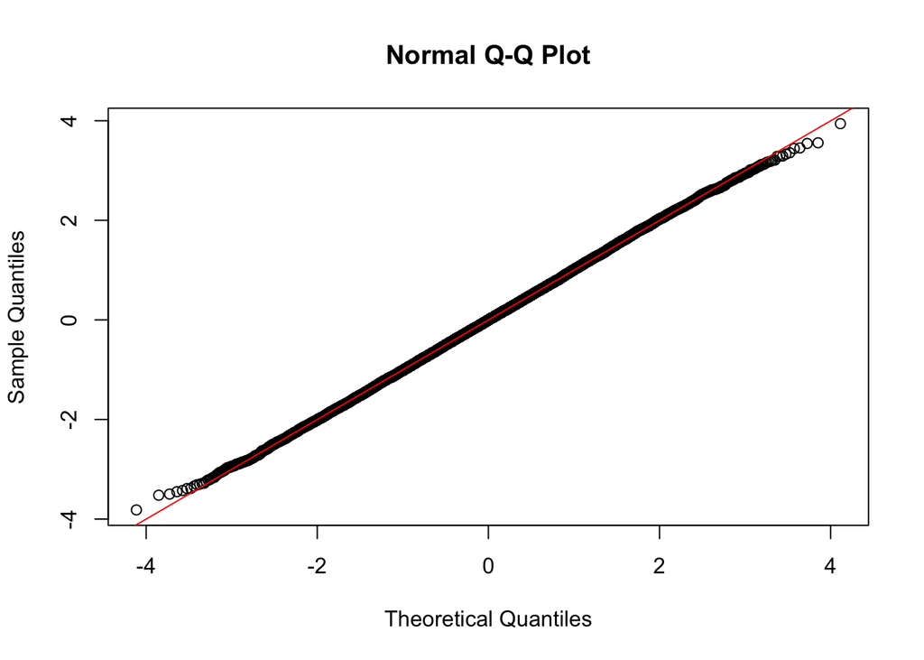

```r
# Check model output - residuals TEST
qqnorm(residuals(prob_life_clusters_many)[which(residuals(prob_life_clusters_many) <
    10000)])
abline(c(0, 1), col = "red")
```

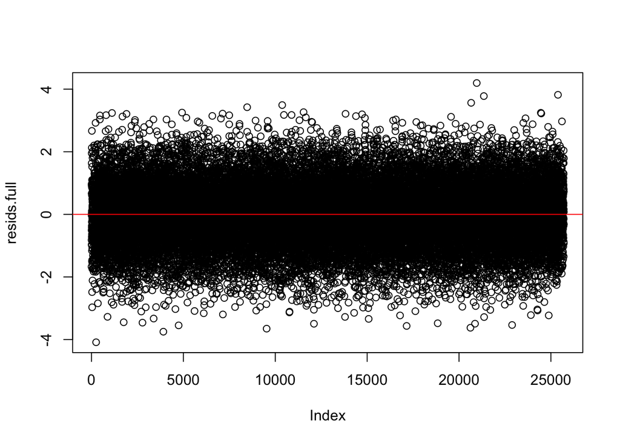

```r
# omit non-finite residuals FULL MODEL
resids.full = residuals(prob_life_clusters_many)[is.finite((residuals(prob_life_clusters_many)))]
plot(resids.full)
abline(c(0, 0), col = "red")
```

Visualise results of traitglm fit with manyglm routine, reference levels are the first cluster group and the mixed albacore life stage group.

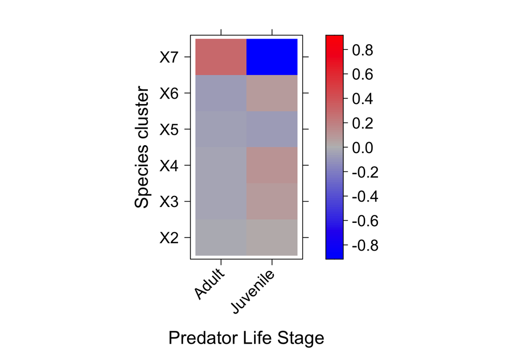

```r
a = max(abs(prob_life_clusters_many$fourth.corner))
colort = colorRampPalette(c("blue", "grey", "red"))  #can replace 'grey' with 'white'
temp = t(as.matrix(prob_life_clusters_many$fourth.corner))

rownames(temp) = c("Adult", "Juvenile")

prob_life_clusters_many_graph = levelplot(temp, xlab = list("Predator Life Stage",
    cex = 1.5), ylab = list("Species cluster", cex = 1.5), col.regions = colort(100),
    at = seq(-a, a, length = 100), scales = list(x = list(rot = 45, cex = 1.3), y = list(cex = 1.3)),
    colorkey = list(labels = list(cex = 1.3)))

print(prob_life_clusters_many_graph)
```

```r
ggsave(here("./outputs_figures/traitglms/prob_all_simple/prob_life_clusters_many_graph.pdf"),
    plot = as.ggplot(prob_life_clusters_many_graph), width = 12, height = 12, dpi = 300)

ggsave(here("outputs_figures/traitglms/prob_all_simple/prob_life_clusters_many_graph.jpeg"),
    plot = as.ggplot(prob_life_clusters_many_graph), width = 12, height = 12, dpi = 300)
```

**GLM1PATH Clusters - Predator Life Stage**

Using method = glm1path == LASSO model.

```r
prob_life_cluster_LASSO <- traitglm(L = alb_prob_preyPA_mv,
                                    R = alb_prob_covars$pred_life,
                                    Q = traits_use$cluster,
                                    family=binomial(link = "logit"),
                                    method="glm1path"
                                    ) #note default is "manyglm"
```

**NOTE:** We do not get a lot of significant values for the clusters as a trait.

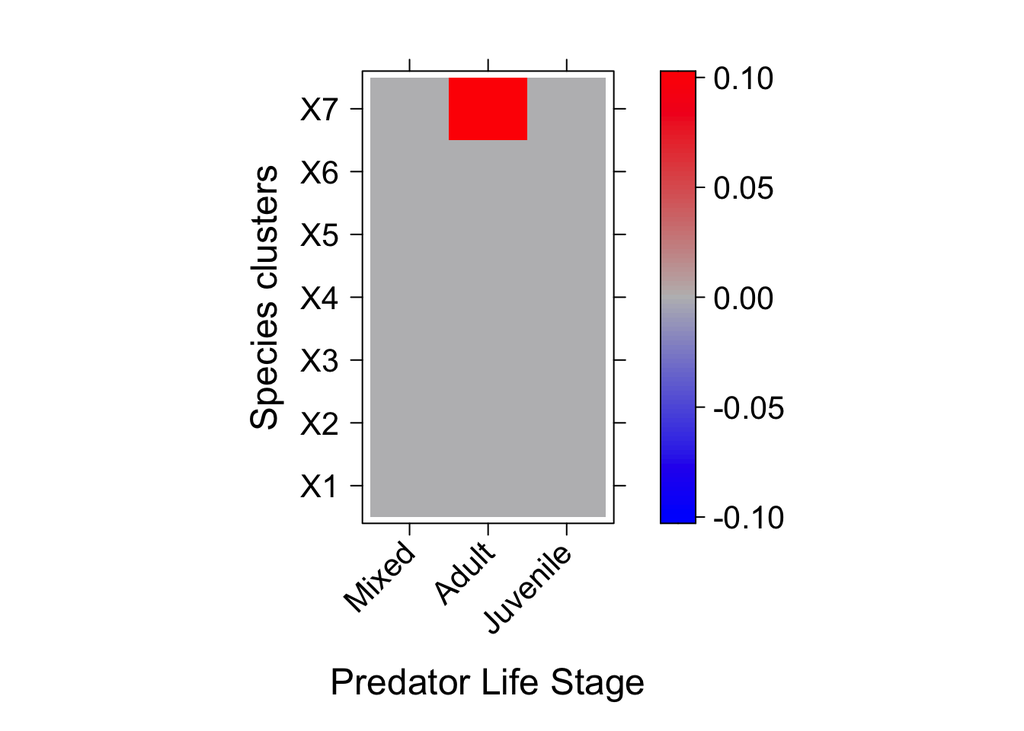

```r
a = max(abs(prob_life_cluster_LASSO$fourth.corner))
colort = colorRampPalette(c("blue", "grey", "red"))  #can replace 'grey' with 'white'
temp = t(as.matrix(prob_life_cluster_LASSO$fourth.corner))

rownames(temp) = c("Mixed", "Adult", "Juvenile")

prob_life_cluster_LASSO_graph = levelplot(temp, xlab = list("Predator Life Stage",
    cex = 1.5), ylab = list("Species clusters", cex = 1.5), col.regions = colort(100),
    at = seq(-a, a, length = 100), scales = list(x = list(rot = 45, cex = 1.3), y = list(cex = 1.3)),
    colorkey = list(labels = list(cex = 1.3)))

print(prob_life_cluster_LASSO_graph)
```

```r
ggsave(here("outputs_figures/traitglms/prob_all_simple/prob_life_cluster7_LASSO_graph.pdf"),
    plot = as.ggplot(prob_life_cluster_LASSO_graph), width = 12, height = 12, dpi = 300)

ggsave(here("outputs_figures/traitglms/prob_all_simple/prob_life_cluster7_LASSO_graph.jpeg"),
    plot = as.ggplot(prob_life_cluster_LASSO_graph), width = 12, height = 12, dpi = 300)
```

#### Ocean Basin

**MANYGLM Clusters - Ocean Basin**

Trait (cluster)*Env (ocean basin) - Manyglm

```r
prob_ocean_clusters_many <- traitglm(L = alb_prob_preyPA_mv,
                                     R = alb_prob_covars$OceanBasin,
                                     Q = traits_use$cluster,
                                     family=binomial(link = "logit")
                                     ) #note default is "manyglm"
```

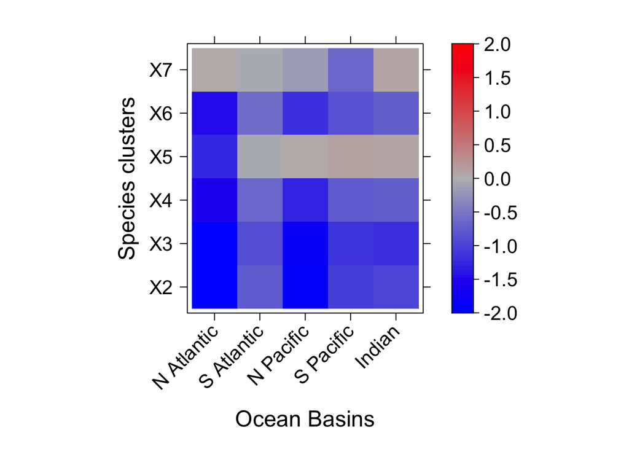

```r
a        = max( abs(prob_ocean_clusters_many$fourth.corner) )
colort   = colorRampPalette(c("blue","grey","red")) #can replace "grey" with "white"
temp = t(as.matrix(prob_ocean_clusters_many$fourth.corner))

rownames(temp) = c(#"Mediterranean",
                   "N Atlantic",
                   "S Atlantic",
                   "N Pacific",
                   "S Pacific",
                   "Indian")

prob_ocean_clusters_many_graph = levelplot(temp,
                     xlab=list("Ocean Basins", cex=1.5),
                     ylab=list("Species clusters", cex=1.5),
                     col.regions=colort(100),
                     at=seq(-a, a,length=100),
                     scales = list(x=list(rot = 45, cex=1.3), y=list(cex=1.3)),
                     colorkey=list(labels=list(cex=1.3)))

print(prob_ocean_clusters_many_graph)
```

```r
ggsave(here("outputs_figures/traitglms/prob_all_simple/prob_ocean_clusters_many_graph.pdf"),
       plot = as.ggplot(prob_ocean_clusters_many_graph), width=12, height=12, dpi=300)

ggsave(here("outputs_figures/traitglms/prob_all_simple/prob_ocean_clusters_many_graph.jpeg"),
       plot = as.ggplot(prob_ocean_clusters_many_graph), width=12, height=12, dpi=300)
```

**GLM1PATH Clusters - Ocean Basin**

Using method = glm1path == LASSO model.

```r
prob_ocean_cluster_LASSO <- traitglm(L = alb_prob_preyPA_mv,
                                     R = alb_prob_covars$OceanBasin,
                                     Q = traits_use$cluster,
                                     family=binomial(link = "logit"),
                                     method="glm1path"
                                     ) #note default is "manyglm"
```

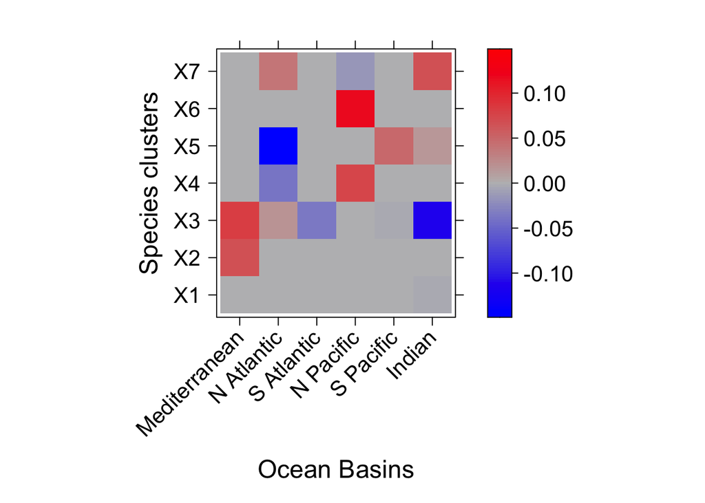

```r
a = max(abs(prob_ocean_cluster_LASSO$fourth.corner))
colort = colorRampPalette(c("blue", "grey", "red"))  #can replace 'grey' with 'white'
temp = t(as.matrix(prob_ocean_cluster_LASSO$fourth.corner))

rownames(temp) = c("Mediterranean", "N Atlantic", "S Atlantic", "N Pacific", "S Pacific",
    "Indian")

prob_ocean_cluster_LASSO_graph = levelplot(temp, xlab = list("Ocean Basins", cex = 1.5),
    ylab = list("Species clusters", cex = 1.5), col.regions = colort(100), at = seq(-a,
        a, length = 100), scales = list(x = list(rot = 45, cex = 1.3), y = list(cex = 1.3)),
    colorkey = list(labels = list(cex = 1.3)))

print(prob_ocean_cluster_LASSO_graph)
```

```r
ggsave(here("outputs_figures/traitglms/prob_all_simple/prob_ocean_cluster_LASSO_graph.pdf"),
    plot = as.ggplot(prob_ocean_cluster_LASSO_graph), width = 12, height = 12, dpi = 300)

ggsave(here("outputs_figures/traitglms/prob_all_simple/prob_ocean_cluster_LASSO_graph.jpeg"),
    plot = as.ggplot(prob_ocean_cluster_LASSO_graph), width = 12, height = 12, dpi = 300)
```

#### SAVE CLUSTER OUTPUTS

```r
#/Users/tashhardy/Documents/GitHub/albacore-diet-global/outputs_figures/traitglms/prob_models

#Manyglms
saveRDS(prob_life_clusters_many, file = here("outputs_figures/traitglms/prob_models/prob_life_clusters_many.rds"))
saveRDS(prob_ocean_clusters_many, file = here("outputs_figures/traitglms/prob_models/prob_ocean_clusters_many.rds"))

#LASSO glms
saveRDS(prob_life_cluster_LASSO, file = here("outputs_figures/traitglms/prob_models/prob_life_cluster_LASSO.rds"))
saveRDS(prob_ocean_cluster_LASSO, file = here("outputs_figures/traitglms/prob_models/prob_ocean_cluster_LASSO.rds"))
```

### Trait models

#### Predator Life Stage

**MANYGLM Trait values - Predator Life Stage**

Trait (trait matrix)*Env (life stage) - Manyglm

```r
prob_life_trait_many <- traitglm(L = alb_prob_preyPA_mv,
                                 R = alb_prob_covars$pred_life,
                                 Q = traits_use[,1:6],
                                    #traits_use_try,
                                 family=binomial(link = "logit")
                                    ) #note default is "manyglm"
```

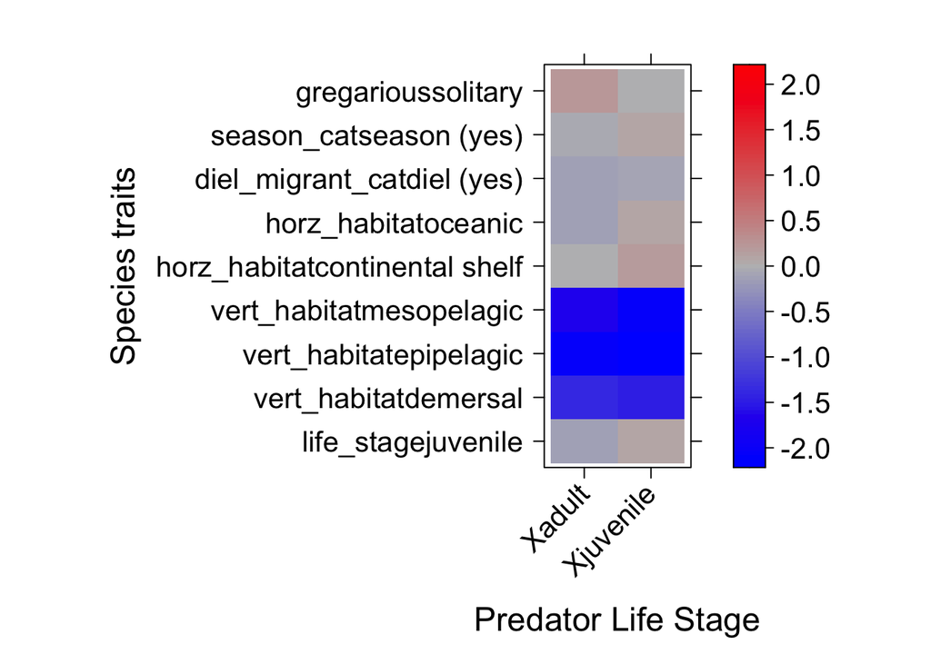

```r
a = max(abs(prob_life_trait_many$fourth.corner))
colort = colorRampPalette(c("blue", "grey", "red"))  #can replace 'grey' with 'white'
temp = t(as.matrix(prob_life_trait_many$fourth.corner))

# rownames(temp) = c('Adult', 'Juvenile', 'Mixed') colnames(temp) = c('Vert.
# habitat - benthic', 'Vert. habitat - demersal', 'Vert. habitat - epipelagic',
# 'Vert. habitat - mesopelagic', 'Vert. habitat - bathypelagic', 'Horz. habitat
# - reef-associated', 'Horz. habitat - coastal', 'Horz. habitat - continental
# shelf', 'Horz. habitat - continental slope', 'Horz. habitat - oceanic', 'Diel
# migrant (yes)', 'Seasonal migrant (yes)', 'Gregarious - schooling')

prob_life_many_4th = levelplot(temp, xlab = list("Predator Life Stage", cex = 1.5),
    ylab = list("Species traits", cex = 1.5), col.regions = colort(100), at = seq(-a,
        a, length = 100), scales = list(x = list(rot = 45, cex = 1.3), y = list(cex = 1.3)),
    colorkey = list(labels = list(cex = 1.3)))

print(prob_life_many_4th)
```

```r
ggsave(here("outputs_figures/traitglms/prob_all_simple/prob_life_many_4th.pdf"),
    plot = as.ggplot(prob_life_many_4th), width = 12, height = 12, dpi = 300)

ggsave(here("outputs_figures/traitglms/prob_all_simple/prob_life_many_4th_graph.jpeg"),
    plot = as.ggplot(prob_ocean_cluster_LASSO_graph), width = 12, height = 12, dpi = 300)

# dev.copy2pdf(file=here('./outputs_figures/traitglms/fourth_lifestage.png'),
# width=12, height=5)
```

**GLM1PATH Trait values - Predator Life Stage**

Using method = glm1path == LASSO model.

```r
prob_life_trait_LASSO <- traitglm(L = alb_prob_preyPA_mv,
                                 R = alb_prob_covars$pred_life,
                                 Q = traits_use[,1:6],
                                 family=binomial(link = "logit"),
                                 method="glm1path"
                                 ) #note default is "manyglm"
```

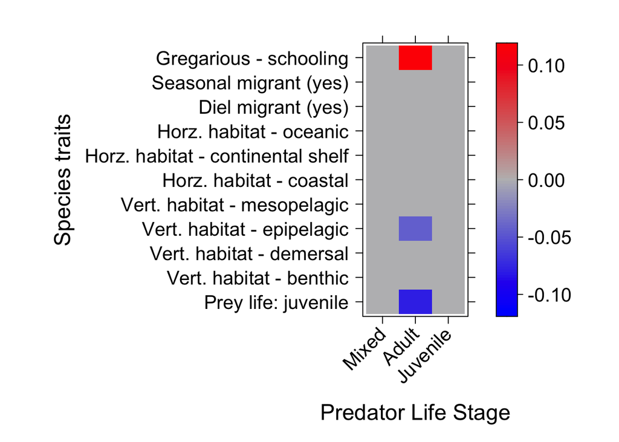

```r
a = max(abs(prob_life_trait_LASSO$fourth.corner))
colort = colorRampPalette(c("blue", "grey", "red"))  #can replace 'grey' with 'white'
temp = t(as.matrix(prob_life_trait_LASSO$fourth.corner))

rownames(temp) = c("Mixed", "Adult", "Juvenile")
colnames(temp) = c("Prey life: juvenile", "Vert. habitat - benthic", "Vert. habitat - demersal",
    "Vert. habitat - epipelagic", "Vert. habitat - mesopelagic", "Horz. habitat - coastal",
    "Horz. habitat - continental shelf", "Horz. habitat - oceanic", "Diel migrant (yes)",
    "Seasonal migrant (yes)", "Gregarious - schooling")

prob_life_LASSO_graph = levelplot(temp, xlab = list("Predator Life Stage", cex = 1.5),
    ylab = list("Species traits", cex = 1.5), col.regions = colort(100), at = seq(-a,
        a, length = 100), scales = list(x = list(rot = 45, cex = 1.3), y = list(cex = 1.3)),
    colorkey = list(labels = list(cex = 1.3)))

print(prob_life_LASSO_graph)
```

```r
ggsave(here("outputs_figures/traitglms/prob_all_simple/prob_life_LASSO_graph.pdf"),
    plot = as.ggplot(prob_life_LASSO_graph), width = 12, height = 12, dpi = 300)

ggsave(here("outputs_figures/traitglms/prob_all_simple/prob_life_LASSO_graph.jpeg"),
    plot = as.ggplot(prob_life_LASSO_graph), width = 12, height = 12, dpi = 300)
```

#### Ocean Basin

**MANYGLM Trait values - Ocean Basin**

Trait (trait matrix)*Env (ocean basin) - Manyglm

```r
prob_ocean_trait_many <- traitglm(L = alb_prob_preyPA_mv,
                                 R = alb_prob_covars$OceanBasin,
                                 Q = traits_use[,1:6],
                                 family=binomial(link = "logit")
                                    ) #note default is "manyglm"
```

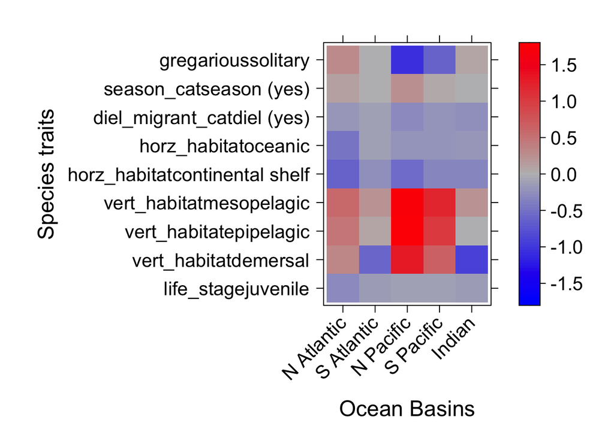

```r
a        = max( abs(prob_ocean_trait_many$fourth.corner) )
colort   = colorRampPalette(c("blue","grey","red")) #can replace "grey" with "white"
temp = t(as.matrix(prob_ocean_trait_many$fourth.corner))

rownames(temp) = c(#"Mediterranean",
                   "N Atlantic",
                   "S Atlantic",
                   "N Pacific",
                   "S Pacific",
                   "Indian")

prob_ocean_trait_many_graph = levelplot(temp,
                     xlab=list("Ocean Basins", cex=1.5),
                     ylab=list("Species traits", cex=1.5),
                     col.regions=colort(100),
                     at=seq(-a, a,length=100),
                     scales = list(x=list(rot = 45, cex=1.3), y=list(cex=1.3)),
                     colorkey=list(labels=list(cex=1.3)))

print(prob_ocean_trait_many_graph)
```

```r
ggsave(here("outputs_figures/traitglms/prob_all_simple/prob_ocean_trait_many_graph.pdf"),
       plot = as.ggplot(prob_ocean_trait_many_graph), width=12, height=12, dpi=300)

ggsave(here("outputs_figures/traitglms/prob_all_simple/prob_ocean_trait_many_graph.jpeg"),
       plot = as.ggplot(prob_ocean_trait_many_graph), width=12, height=12, dpi=300)
```

*GLM1PATH Trait values - Ocean Basin**

Using method = glm1path == LASSO model.

```r
prob_ocean_trait_LASSO <- traitglm(L = alb_prob_preyPA_mv,
                                 R = alb_prob_covars$OceanBasin,
                                 Q = traits_use[,1:6],
                                 family=binomial(link = "logit"),
                                 method="glm1path"
                                 ) #note default is "manyglm"
```

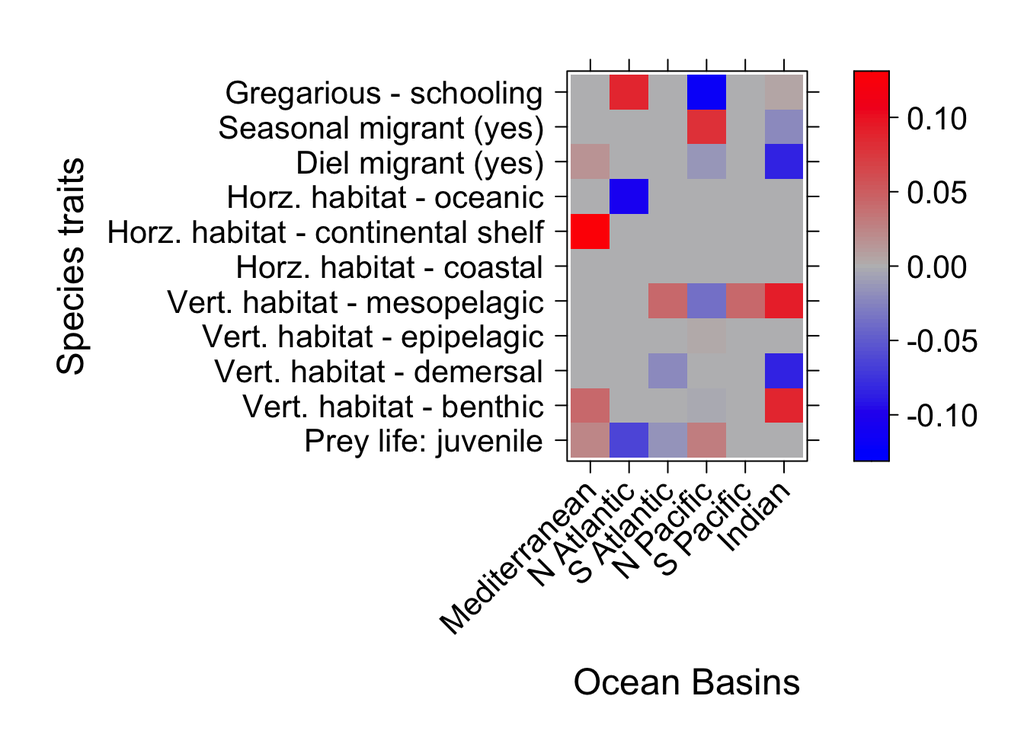

```r
a = max(abs(prob_ocean_trait_LASSO$fourth.corner))
colort = colorRampPalette(c("blue", "grey", "red"))  #can replace 'grey' with 'white'
temp = t(as.matrix(prob_ocean_trait_LASSO$fourth.corner))

rownames(temp) = c("Mediterranean", "N Atlantic", "S Atlantic", "N Pacific", "S Pacific",
    "Indian")

colnames(temp) = c("Prey life: juvenile", "Vert. habitat - benthic", "Vert. habitat - demersal",
    "Vert. habitat - epipelagic", "Vert. habitat - mesopelagic", "Horz. habitat - coastal",
    "Horz. habitat - continental shelf", "Horz. habitat - oceanic", "Diel migrant (yes)",
    "Seasonal migrant (yes)", "Gregarious - schooling")

prob_ocean_LASSO_graph = levelplot(temp, xlab = list("Ocean Basins", cex = 1.5),
    ylab = list("Species traits", cex = 1.5), col.regions = colort(100), at = seq(-a,
        a, length = 100), scales = list(x = list(rot = 45, cex = 1.3), y = list(cex = 1.3)),
    colorkey = list(labels = list(cex = 1.3)))

print(prob_ocean_LASSO_graph)
```

```r
ggsave(here("outputs_figures/traitglms/prob_all_simple/prob_ocean_LASSO_graph.pdf"),
    plot = as.ggplot(prob_ocean_LASSO_graph), width = 12, height = 12, dpi = 300)

ggsave(here("outputs_figures/traitglms/prob_all_simple/prob_ocean_LASSO_graph.jpeg"),
    plot = as.ggplot(prob_ocean_LASSO_graph), width = 12, height = 12, dpi = 300)
```

#### Temperate / Tropical

**MANYGLM Trait values - Latitude**

Trait (trait matrix)*Env (latitude) - Manyglm

```r
prob_lat_trait_many <-  traitglm(L = alb_prob_preyPA_mv,
                            R = alb_prob_covars$lat_cat,
                            Q = traits_use[,1:6],
                            family=binomial(link = "logit")
                            ) #note default is "manyglm"
```

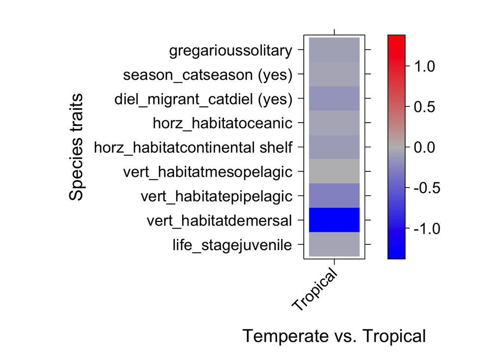

```r
a = max(abs(prob_lat_trait_many$fourth.corner))
colort = colorRampPalette(c("blue", "grey", "red"))  #can replace 'grey' with 'white'
temp = t(as.matrix(prob_lat_trait_many$fourth.corner))

rownames(temp) = c("Tropical")

prob_lat_trait_many_graph = levelplot(temp, xlab = list("Temperate vs. Tropical",
    cex = 1.5), ylab = list("Species traits", cex = 1.5), col.regions = colort(100),
    at = seq(-a, a, length = 100), scales = list(x = list(rot = 45, cex = 1.3), y = list(cex = 1.3)),
    colorkey = list(labels = list(cex = 1.3)))

print(prob_lat_trait_many_graph)
```

```r
# ggsave(here('outputs_figures/traitglms/prob_all_simple/prob_lat_trait_many_graph.pdf'),
# plot = as.ggplot(prob_lat_trait_many_graph), width=12, height=12, dpi=300)

# ggsave(here('outputs_figures/traitglms/prob_all_simple/prob_lat_trait_many_graph.jpeg'),
# plot = as.ggplot(prob_lat_trait_many_graph), width=12, height=12, dpi=300)
```

**GLM1PATH Trait values - Latitude**

Using method = glm1path == LASSO model.

```r
#levels(alb_prob_covars$lat_cat)

#alb_prob_covars$lat_cat <- factor(alb_prob_covars$lat_cat, levels = c("tropical", "temperate"))

prob_lat_trait_LASSO <-  traitglm(L = alb_prob_preyPA_mv,
                            R = alb_prob_covars$lat_cat,
                            Q = traits_use[,1:6],
                            family=binomial(link = "logit"),
                            method="glm1path"
                            ) #note default is "manyglm"
```

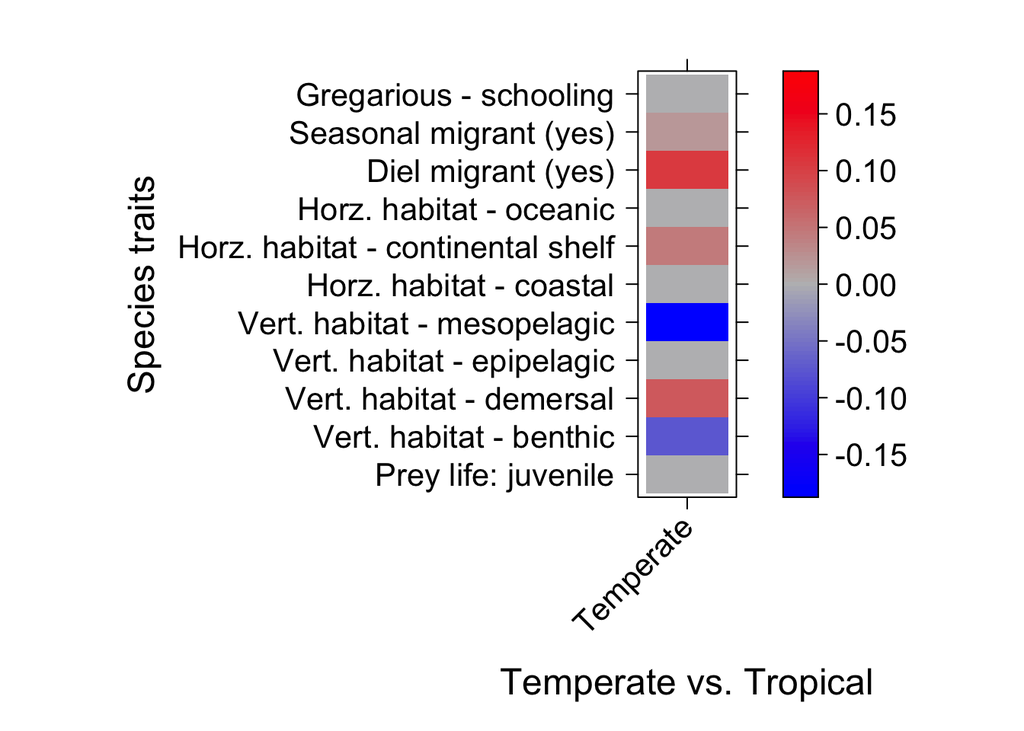

```r
a = max(abs(prob_lat_trait_LASSO$fourth.corner))
colort = colorRampPalette(c("blue", "grey", "red"))  #can replace 'grey' with 'white'
temp = t(as.matrix(prob_lat_trait_LASSO$fourth.corner))

rownames(temp) = c("Temperate")

colnames(temp) = c("Prey life: juvenile", "Vert. habitat - benthic", "Vert. habitat - demersal",
    "Vert. habitat - epipelagic", "Vert. habitat - mesopelagic", "Horz. habitat - coastal",
    "Horz. habitat - continental shelf", "Horz. habitat - oceanic", "Diel migrant (yes)",
    "Seasonal migrant (yes)", "Gregarious - schooling")


prob_lat_trait_LASSO_graph = levelplot(temp, xlab = list("Temperate vs. Tropical",
    cex = 1.5), ylab = list("Species traits", cex = 1.5), col.regions = colort(100),
    at = seq(-a, a, length = 100), scales = list(x = list(rot = 45, cex = 1.3), y = list(cex = 1.3)),
    colorkey = list(labels = list(cex = 1.3)))

print(prob_lat_trait_LASSO_graph)
```

```r
# ggsave(here('outputs_figures/traitglms/prob_all_simple/prob_lat_trait_LASSO_temp_graph.pdf'),
# plot = as.ggplot(prob_lat_trait_LASSO_graph), width=12, height=12, dpi=300)

# ggsave(here('outputs_figures/traitglms/prob_all_simple/prob_lat_trait_LASSO_emp_graph.jpeg'),
# plot = as.ggplot(prob_lat_trait_LASSO_graph), width=12, height=12, dpi=300)
```

#### SAVE TRAITS OUTPUTS

```r
# Manyglms
saveRDS(prob_life_trait_many, file = here("outputs_figures/traitglms/prob_models/prob_life_trait_many.rds"))
saveRDS(prob_ocean_trait_many, file = here("outputs_figures/traitglms/prob_models/prob_ocean_trait_many.rds"))
saveRDS(prob_lat_trait_many, file = here("outputs_figures/traitglms/prob_models/prob_lat_trait_many.rds"))

#LASSO glms
saveRDS(prob_life_trait_LASSO, file = here("outputs_figures/traitglms/prob_models/prob_life_trait_LASSO.rds"))
saveRDS(prob_ocean_trait_LASSO, file = here("outputs_figures/traitglms/prob_models/prob_ocean_trait_LASSO.rds"))
saveRDS(prob_lat_trait_LASSO, file = here("outputs_figures/traitglms/prob_models/prob_lat_trait_LASSO.rds"))
```

### Interactions

**MANYGLM Interaction Model**

```r
prob_inter_trait_many <- traitglm(L = alb_prob_preyPA_mv,
                                  R = alb_prob_covars[,c(4,12)],
                                  Q = traits_use[,1:6],
                                  family=binomial(link = "logit")
                                    ) #note default is "manyglm"
```

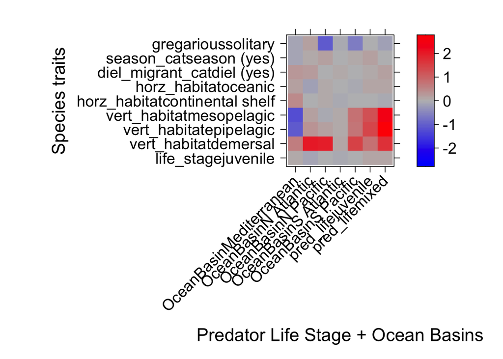

```r
a = max(abs(prob_inter_trait_many$fourth.corner))
colort = colorRampPalette(c("blue", "grey", "red"))  #can replace 'grey' with 'white'
temp = t(as.matrix(prob_inter_trait_many$fourth.corner))

prob_inter_trait_many_graph = levelplot(temp, xlab = list("Predator Life Stage + Ocean Basins",
    cex = 1.5), ylab = list("Species traits", cex = 1.5), col.regions = colort(100),
    at = seq(-a, a, length = 100), scales = list(x = list(rot = 45, cex = 1.3), y = list(cex = 1.3)),
    colorkey = list(labels = list(cex = 1.3)))

print(prob_inter_trait_many_graph)
```

```r
ggsave(here("outputs_figures/traitglms/prob_all_simple/prob_inter_trait_many_graph.pdf"),
    plot = as.ggplot(prob_inter_trait_many_graph), width = 12, height = 12, dpi = 300)

ggsave(here("outputs_figures/traitglms/prob_all_simple/prob_inter_trait_many_graph.jpeg"),
    plot = as.ggplot(prob_inter_trait_many_graph), width = 12, height = 12, dpi = 300)
```

**GLM1PATH Interaction Model**

```r
prob_inter_trait_LASSO <- traitglm(L = alb_prob_preyPA_mv,
                                  R = alb_prob_covars[,c(4,12)],
                                  Q = traits_use[,1:6],
                                  family=binomial(link = "logit"),
                                  method="glm1path"
                                    ) #note default is "manyglm"
```

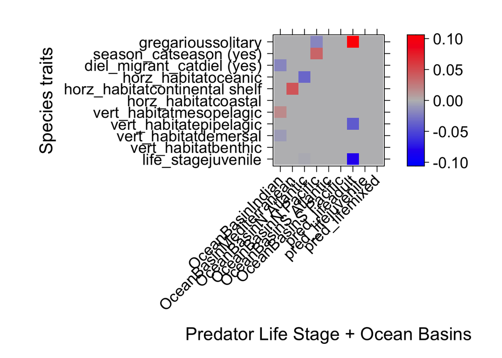

```r
a = max(abs(prob_inter_trait_LASSO$fourth.corner))
colort = colorRampPalette(c("blue", "grey", "red"))  #can replace 'grey' with 'white'
temp = t(as.matrix(prob_inter_trait_LASSO$fourth.corner))

prob_inter_trait_LASSO_graph = levelplot(temp, xlab = list("Predator Life Stage + Ocean Basins",
    cex = 1.5), ylab = list("Species traits", cex = 1.5), col.regions = colort(100),
    at = seq(-a, a, length = 100), scales = list(x = list(rot = 45, cex = 1.3), y = list(cex = 1.3)),
    colorkey = list(labels = list(cex = 1.3)))

print(prob_inter_trait_LASSO_graph)
```

```r
ggsave(here("outputs_figures/traitglms/prob_all_simple/prob_inter_trait_LASSO_graph.pdf"),
    plot = as.ggplot(prob_inter_trait_LASSO_graph), width = 12, height = 12, dpi = 300)

ggsave(here("outputs_figures/traitglms/prob_all_simple/prob_inter_trait_many_graph.jpeg"),
    plot = as.ggplot(prob_inter_trait_LASSO_graph), width = 12, height = 12, dpi = 300)
```

SAVE THESE

```r
#Manyglm
saveRDS(prob_inter_trait_many, file = here("outputs_figures/traitglms/prob_models/prob_inter_trait_many.rds"))

#LASSO glms
saveRDS(prob_inter_trait_LASSO, file = here("outputs_figures/traitglms/prob_models/prob_inter_trait_LASSO.rds"))
```

### MODEL COMPARISON

#### Model Outputs

Cluster, trait, spp models each for (i) predator life stage and (ii) ocean basins

##### Model: prob_life_spp

```r
prob_life_spp
```

```
##
## Call:  traitglm(L = alb_prob_preyPA_mv, R = alb_prob_covars$pred_life,      family = binomial(link = "logit"))
## [1] "binomial(link=logit)"
##
## Degrees of Freedom: 25706 Total (i.e. Null); 25338 Residual
##
##                     l
## 2*log-likelihood:   -3329
## Residual Deviance:   3329
## AIC:                 4067
```

##### Model: prob_ocean_spp

```r
prob_ocean_spp
```

```
##
## Call:  traitglm(L = alb_prob_preyPA_mv, R = alb_prob_covars$OceanBasin,      family = binomial(link = "logit"))
## [1] "binomial(link=logit)"
##
## Degrees of Freedom: 25706 Total (i.e. Null); 24969 Residual
##
##                     l
## 2*log-likelihood:   -2978
## Residual Deviance:   2978
## AIC:                 4454
```

##### Model: prob_lat_spp

```r
prob_lat_spp
```

```
##
## Call:  traitglm(L = alb_prob_preyPA_mv, R = alb_prob_covars$lat_cat,      family = binomial(link = "logit"))
## [1] "binomial(link=logit)"
##
## Degrees of Freedom: 25706 Total (i.e. Null); 25461 Residual
##
##                     l
## 2*log-likelihood:   -3656
## Residual Deviance:   3656
## AIC:                 4148
```

##### Model: prob_life_clusters_many

```r
prob_life_clusters_many
```

```
##
## Call:  traitglm(L = alb_prob_preyPA_mv, R = alb_prob_covars$pred_life,      Q = traits_prob$cluster, family = binomial(link = "logit"))
## [1] "binomial(link=logit)"
##
## Degrees of Freedom: 25706 Total (i.e. Null); 25570 Residual
##
##                     l
## 2*log-likelihood:   -3806
## Residual Deviance:   3806
## AIC:                 4080
```

##### Model: prob_ocean_clusters_many

```r
prob_ocean_clusters_many
```

```
##
## Call:  traitglm(L = alb_prob_preyPA_mv, R = alb_prob_covars$OceanBasin,      Q = traits_prob$cluster, family = binomial(link = "logit"))
## [1] "binomial(link=logit)"
##
## Degrees of Freedom: 25706 Total (i.e. Null); 25549 Residual
##
##                     l
## 2*log-likelihood:   -3776
## Residual Deviance:   3776
## AIC:                 4092
```

##### Model: prob_life_trait_many

```r
prob_life_trait_many
```

```
##
## Call:  traitglm(L = alb_prob_preyPA_mv, R = alb_prob_covars$pred_life,      Q = traits_use[, 1:6], family = binomial(link = "logit"))
## [1] "binomial(link=logit)"
##
## Degrees of Freedom: 25706 Total (i.e. Null); 25564 Residual
##
##                     l
## 2*log-likelihood:   -3764
## Residual Deviance:   3764
## AIC:                 4050
```

##### Model: prob_ocean_trait_many

```r
prob_ocean_trait_many
```

```
##
## Call:  traitglm(L = alb_prob_preyPA_mv, R = alb_prob_covars$OceanBasin,      Q = traits_use[, 1:6], family = binomial(link = "logit"))
## [1] "binomial(link=logit)"
##
## Degrees of Freedom: 25706 Total (i.e. Null); 25534 Residual
##
##                     l
## 2*log-likelihood:   -3746
## Residual Deviance:   3746
## AIC:                 4092
```

##### Model: prob_lat_trait_many

```r
prob_lat_trait_many
```

```
##
## Call:  traitglm(L = alb_prob_preyPA_mv, R = alb_prob_covars$lat_cat,      Q = traits_use[, 1:6], family = binomial(link = "logit"))
## [1] "binomial(link=logit)"
##
## Degrees of Freedom: 25706 Total (i.e. Null); 25574 Residual
##
##                     l
## 2*log-likelihood:   -3875
## Residual Deviance:   3875
## AIC:                 4141
```

##### Model: prob_inter_trait_many

```r
prob_inter_trait_many
```

```
##
## Call:  traitglm(L = alb_prob_preyPA_mv, R = alb_prob_covars[, c(4, 12)],      Q = traits_use[, 1:6], family = binomial(link = "logit"))
## [1] "binomial(link=logit)"
##
## Degrees of Freedom: 25706 Total (i.e. Null); 25514 Residual
##
##                     l
## 2*log-likelihood:   -3634
## Residual Deviance:   3634
## AIC:                 4020
```

## Conclusions

The species models had the lowest residual deviance explained, and typically higher AIC values./ Cluster models performed slightly better than traits models, but not massive difference. Both cluster and trait sets of models outperformed species models.

The best model in terms of residual deviance explained was the latitude + traits model, however, did have higher AIC scores. The interaction model that included ocean basin + life stage had the lowest AIC but low deviance explained.